# Federal Anchor Transmission: Paired-Line Architecture for HVDC Pilots

## The Two Lines

Each HVDC anchor corridor carries two parallel ±525 kV HVDC lines sharing right-of-way (with appropriate inter-line spacing for redundancy purposes), shared permitting and siting processes, shared converter station siting, and shared ownership pattern (TVA segment in the home jurisdiction, federal cross-jurisdictional segment, destination IOU AC leg with 35% economic stake in the receiving converter station). The shared treatment minimizes the marginal cost of the second line and ensures both lines move through regulatory approval together rather than on staggered timelines.

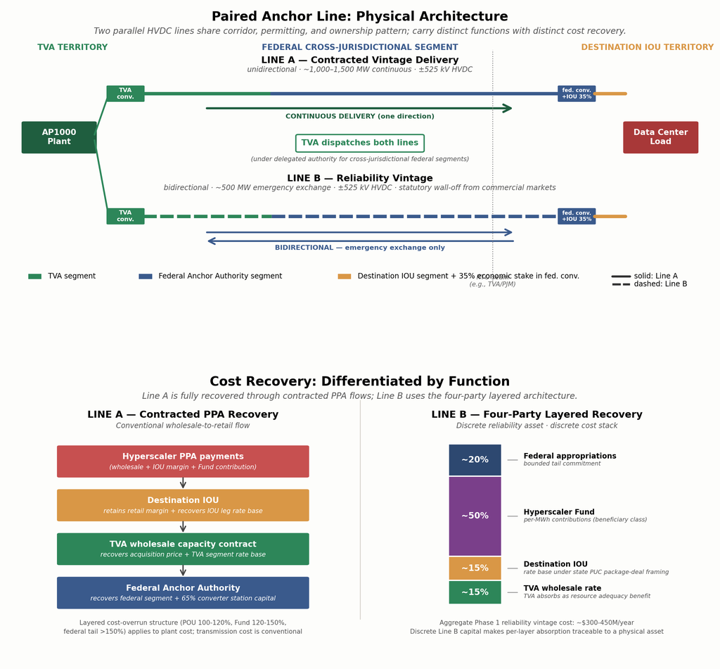

Paired anchor line physical architecture (top) and cost recovery (bottom). Line A is a unidirectional HVDC link that delivers contracted clean firm vintage from the federally-built plant to the destination IOU continuously, recovered through conventional wholesale-to-retail PPA flows. Line B is a smaller bidirectional HVDC link that handles emergency exchange between TVA and the destination IOU’s host region, reserved by statute for emergency exchange use only and recovered through the four-party layered architecture (TVA ~15%, destination IOU ~15%, hyperscaler Reserve Fund ~50%, federal appropriations ~20%). TVA dispatches both lines under delegated authority for the cross-jurisdictional federal segments.

**Line A — Contracted Vintage Delivery** is sized to contracted capacity per pilot: approximately 1,200 MW for Hartsville→Charlotte, 1,500 MW for Clinch River→Northern Virginia, 1,000 MW for Yellow Creek→Central MS. The line operates as a unidirectional HVDC link: power flows from the federally-built plant toward the destination IOU at contracted output level, continuously, with normal operational variation only for routine maintenance windows. TVA dispatches Line A under its existing operational authority over the home segment plus delegated authority over the federal cross-jurisdictional segment. The destination IOU’s AC integration at the receiving converter station follows normal RTO scheduling protocols for the AC infrastructure it owns. The line’s capacity is fully committed to the contracted wholesale capacity contract between TVA and the destination IOU; there is no reserved headroom for non-contracted purposes.

Line A’s cost recovery is conventional. The hyperscaler retail PPA payments flow to the destination IOU, which retains retail margin and recovers its IOU leg rate base, then passes the wholesale price through to TVA, which recovers acquisition price plus TVA segment rate base. Federal cost recovery on the federal cross-jurisdictional segment of Line A flows through the wholesale capacity arrangement (the Federal Anchor Authority charges TVA a segment usage fee that TVA passes through to the wholesale rate, ultimately recovered through the hyperscaler PPA). The layered cost-overrun architecture (POU 100-120%, hyperscaler Reserve Fund 120-150%, federal tail above 150%) applies to plant construction cost as in Version 2.0; transmission cost on Line A is recovered conventionally without the cost-overrun layered structure because transmission construction is substantially less risk-volatile than nuclear construction.

**Line B — Reliability Vintage** is sized at 500 MW per pilot (chosen as a single specification rather than the 300-500 MW range in the Version 2.0 single-line design, because the discrete physical asset makes the size decision more visible and the bias toward larger sizing improves the value proposition). The line operates as a bidirectional HVDC link with no continuous contracted flow; capacity is reserved for emergency exchange in either direction during defined stress conditions. In normal operations, Line B carries minimal flow (occasional grid-stabilization adjustments, system testing, scheduled maintenance verification) but is fully available for emergency dispatch when conditions require.

Line B is statutorily reserved for emergency exchange use only. The federal authorizing legislation explicitly prohibits Line B from participating in commercial dispatch markets, including any RTO or ISO market mechanism, any energy imbalance market (including SEEM expansion or future Western-EIM-style arrangements east of the Mississippi), and any bilateral commercial dispatch arrangement with neighboring utilities outside defined emergency protocols. The statutory protection identifies Line B as the protected asset by physical and ownership specification, not by reference to a category of capacity on a shared line.

TVA dispatches Line B under the same delegated authority structure that governs Line A. The dispatch authority is integrated: TVA’s control room manages both lines as components of TVA’s resource adequacy posture, not as separately operated assets. When TVA experiences asymmetric stress conditions, TVA’s dispatcher determines whether emergency import on Line B is appropriate; when the destination region experiences asymmetric stress and TVA is in a position to help, TVA’s dispatcher coordinates with the destination RTO to determine whether emergency export on Line B is appropriate. The operational decision-making structure is unitary; the physical architecture is paired.

The paired architecture is HVDC-specific. AC power flows on parallel AC lines follow the network’s physics of impedance and voltage angle differences, not dispatcher direction; building two parallel AC lines does not produce two functionally separated lines, because the flow on each is determined by network conditions and both lines share the load according to their relative impedance. For the Bellefonte→Atlanta AC pilot, the paired architecture does not apply; that pilot continues as the Version 2.0 single-line design with reliability headroom embedded in the integrated line and dispatched as part of TVA’s operational management of the corridor. The asymmetric treatment across the four Phase 1 pilots is not a problem — Bellefonte→Atlanta connects regions (TVA and Southern Company) with relatively closely correlated weather and grid conditions, where asymmetric stress events are less frequent than across the longer-distance, larger-thermal-load-region transitions to PJM and MISO South, so the operational cost of single-line design is correspondingly smaller.

## Capital Cost Analysis

The capital cost increment per HVDC pilot decomposes into three components: incremental line construction, incremental converter station construction, and incremental shared infrastructure.

**Line construction increment** is the principal cost driver but smaller in absolute terms than might be expected. ±525 kV HVDC line construction in the 300-450 mile range that the Phase 1 HVDC pilots span runs approximately $1.5-2.5 million per mile depending on terrain, ROW characteristics, and labor market conditions. For a representative 350-mile line, total construction is $525-875 million. The increment for a second parallel line on the same corridor is modestly lower per-mile than the first line because shared survey work, shared environmental review, shared community engagement, and shared crew mobilization reduce some non-construction costs — perhaps 15-25% lower per mile, producing an incremental line construction cost of $400-700 million for the second line on a 350-mile corridor.

**Converter station construction increment** is the principal cost concern. HVDC converter stations are expensive and engineering-intensive; a ±525 kV converter station for a 1,000-1,500 MW link runs $200-500 million on each end of the line, totaling $400 million to $1 billion per HVDC link. The paired architecture requires duplicate converter stations at both ends, but the smaller Line B (500 MW) requires smaller converter stations than the contracted Line A (~1,200 MW reference), perhaps 50-65% of Line A converter station cost. Incremental converter station cost for the Line B pair is approximately $200-650 million.

**Shared infrastructure increment** is modest. Shared corridor permitting and siting work largely apply to both lines simultaneously, with marginal increments for the second line’s environmental review supplements and inter-line spacing requirements. Shared substation interconnection at the plant end and at the destination IOU end can largely accommodate both lines without proportional expansion. The increment for shared infrastructure is approximately $50-150 million per pilot.

The total capital cost increment per HVDC pilot is approximately $650 million to $1.5 billion, with $1.0-1.2 billion as a reasonable mid-range estimate. Across the three Phase 1 HVDC pilots, aggregate incremental capital is approximately $3-4.5 billion, mid-range estimate $3.3 billion.

The Phase 1 program total capital reference is approximately $80-100 billion (four nuclear plants at $14-18 billion each plus four transmission corridors at $2-5 billion each in single-line design), so the paired-line architecture’s capital increment represents 3-5% of total Phase 1 program capital. The annualized carrying cost increment is approximately $250-350 million per year (using a 30-year amortization and a blended cost of capital appropriate to the layered ownership structure).

The carrying cost translates to a hyperscaler Reserve Fund contribution increment of approximately $3-5/MWh on top of the Version 2.0 contribution rate. The total Fund contribution rate under the paired architecture is therefore approximately $21-32/MWh, compared to $18-27/MWh under Version 2.0. For a hyperscaler offtaking 1,000 MW at 90% capacity factor, the Fund contribution under the paired architecture is approximately $165-250 million per year per plant, compared to $140-215 million per year under Version 2.0. Across the Phase 1 fleet, aggregate hyperscaler contributions are roughly $660 million to $1 billion per year, compared to $560-860 million per year under Version 2.0.

This is a real increment but not transformative. It remains well below the $40-55/MWh that single-payer single-layer approaches would require, and the layered architecture continues to keep no single party bearing catastrophic absorption. The incremental cost is justified by the operational benefits, particularly the contracted delivery reliability that the paired architecture provides to hyperscalers.

## The Cleaner Cost Recovery Story

The paired-line architecture substantially clarifies the cost recovery story compared to the Version 2.0 single-line design. Under Version 2.0, the reliability vintage carrying cost is recovered through a layered architecture (TVA ~15%, destination IOU ~15%, hyperscaler Fund ~50%, federal appropriations ~20%), but the “reliability vintage” is operationally a capacity allocation on an integrated line rather than a discrete asset. The state PUC’s prudency review for the destination IOU’s 15% absorption layer has to defend an allocation methodology — what portion of the integrated line’s capital is appropriately attributed to the reliability vintage and therefore appropriately subject to the destination IOU’s rate-base absorption. This is doable but requires the state PUC to engage with allocation methodology that is somewhat abstract relative to standard rate-base prudency analysis.

Under the paired architecture, the reliability vintage is a discrete physical asset (Line B) with discrete capital cost. The state PUC’s prudency review has a concrete subject: this line costs X to construct, the destination IOU absorbs 15% of carrying cost on this specific line, which is Y per year, which is Z per retail customer per month, in exchange for the broader package of benefits the destination state receives from federal anchor program participation. The package-deal framing developed in the main proposal becomes structurally cleaner because the reliability infrastructure is a discrete asset rather than an accounting allocation.

The discrete asset also simplifies federal appropriations accounting. The federal appropriations layer (~20% of reliability vintage carrying cost) under Version 2.0 had to be implemented as appropriations earmarked against a notional layer of an integrated asset; under the paired architecture, the appropriations support a discrete asset whose capital cost is transparent and whose operational status is verifiable. Appropriations cycle scrutiny may be more aggressive against discrete assets (this is the commercialization-as-wedge concern addressed below), but the accounting is cleaner.

Hyperscaler Fund contributions are similarly simplified. The Fund’s ~50% absorption of reliability vintage carrying cost under Version 2.0 had to be sized as a per-MWh contribution rate calibrated against an allocation of an integrated asset’s carrying cost; under the paired architecture, the Fund’s contribution corresponds to a discrete physical asset with discrete cost. Hyperscaler procurement teams reviewing the contribution structure can more directly evaluate what their per-MWh contribution is funding.

TVA’s ~15% wholesale rate absorption follows the same cleaner pattern. TVA’s wholesale rate construction can attribute a discrete portion of overall rates to Line B carrying cost rather than allocating from an integrated line’s carrying cost. TVA’s accountability to its 153 LPCs and through them to ~10 million retail customers benefits from the cleaner attribution.

## Constituency Effects

The paired-line architecture has differentiated effects across the constituency groups identified in the political analysis, with effects generally favorable but one significant complication.

**Destination IOUs (Southern, Duke, Dominion, Entergy MS)** experience net positive effects from the paired architecture. The transmission rate base position is larger — two segments per pilot instead of effectively one, with discrete capital costs and discrete cost recovery treatment. State PUC proceedings become cleaner: rather than absorbing 15% of an integrated line’s reliability vintage allocation, the IOU absorbs 15% of a discrete reliability line whose capital cost is transparent. The package-deal framing arguments become structurally clearer because the reliability infrastructure is a discrete asset rather than an accounting allocation. The IOU does bear modestly more capital cost on its share (proportionally larger transmission rate base means proportionally larger IOU absorption), but the rate-base position is also larger — net positive in IOU rate-recovery terms. The IOU minority co-ownership mitigation continues to work, with thought needed about whether minority co-ownership applies symmetrically to Line A and Line B or differently to each. On balance, the paired architecture makes the IOU politics slightly easier.

**Hyperscalers** experience materially better outcomes. The single largest hyperscaler concern with long-term clean firm PPAs is delivery reliability — the contracted volume must actually flow when needed, particularly during stress conditions. Under the single-line design, contracted clean firm delivery is structurally exposed to interruption during exactly the conditions when hyperscalers need it most. The paired architecture eliminates that exposure: contracted delivery on Line A is never diverted for reliability purposes. The $3-5/MWh contribution increment is almost certainly something hyperscalers would willingly pay for this delivery guarantee — it converts an implicit interruption risk into an explicit reliability guarantee. Hyperscaler buy-in for the program improves; Fund contribution negotiations become easier because hyperscalers are getting more for their contribution.

**TVA** experiences significantly improved operational posture. The resource adequacy story under stress becomes much cleaner: emergency exchange capability is available without forcing TVA to choose between contractual obligations and in-territory reliability. TVA’s home-segment dispatch authority over each line is preserved, with potentially clearer operating protocols because Line A and Line B have distinct purposes. TVA bears some additional capital cost on its home-jurisdiction segments of the reliability lines, but the dispatch reliability and reduced contractual exposure are operationally valuable. The TVA CEO’s commitment that data center growth won’t pressure rates for other electric customers is structurally easier to defend under the paired architecture because the reliability line’s costs are discretely traceable and the contracted line is fully covered by hyperscaler payments rather than relying on allocation rules.

**State PUCs** benefit from the cleaner package-deal framing. The PUC’s prudency review for the destination IOU’s absorption layer has a discrete asset to evaluate: this line costs X, the IOU absorbs 15% which is Y per year, which is Z per retail customer per month. That is a cleaner argument than “the integrated line has reliability vintage capacity which the IOU is partially absorbing through allocation.” Virginia’s case in particular probably becomes slightly easier — the State Corporation Commission’s questioning around what specifically is being rate-based has a clearer answer when the answer is a discrete piece of physical infrastructure rather than an allocated capacity layer.

**The interregional transmission advocate community** (Grid Strategies, Brattle, Niskanen, ACEG, ESIG, RMI) experiences mixed effects. On the positive side, the discrete reliability line is more amenable to ELCC accreditation in a way that the embedded reliability vintage on an integrated line is harder to accredit. PJM and MISO would still need to develop accreditation mechanisms (PJM today gives “zero value to new interregional transmission” per Pfeifenberger), but the discrete reliability asset is a cleaner candidate for accreditation. The advocate community could potentially endorse a structure where Line A operates conventionally with no special advocate-community attention and Line B is the structural innovation that gets ELCC accreditation. The “compensate, don’t isolate” frame fits Line B more cleanly than it fits the embedded reliability vintage. On the negative side, the discrete reliability line is significantly more vulnerable to commercialization-as-wedge pressure, which the advocate community as a class would view favorably and the program design needs to defend against.

**Independent power producers** (Constellation, etc.) experience no material change in their relationship to the program from the paired architecture. The IPP opposition is principally about the public-preference principle restriction on plant acquirers and the federal cost-overrun absorption structure for plants, neither of which changes under the paired architecture. The paired architecture has essentially no incremental effect on IPP politics.

## Commercialization-as-Wedge: A More Robust Defense

The discrete reliability line is significantly more vulnerable to commercialization-as-wedge pressure than the embedded reliability vintage in the Version 2.0 single-line design. The integrated reliability vintage is somewhat structurally protected by being tangled up with contracted delivery on the same physical line: arguments to commercialize “the reliability vintage” require dealing with the operational entanglement, and the practical case for an entirely separate market dispatch on a single integrated line is awkward. Under the paired architecture, Line B is a discrete, dispatchable physical asset with its own converter stations, dedicated capacity, and clear operational identity. Future political pressure to commercialize Line B has a clear physical target.

Imagine a future appropriations cycle when federal commitment is being scrutinized. “Line B is a 500 MW HVDC link that flows almost never; let it participate in EIM so it can earn revenue and reduce federal appropriations.” That argument is harder to make against the Version 2.0 single-line design because there is no discrete Line B — there is just a line with headroom. Under the paired architecture, the argument has clean physical referent and proper accounting. The discrete asset is a permanent political target in a way that the embedded reliability vintage isn’t quite.

The defense against this vulnerability is operational rather than purely statutory. TVA dispatches both Line A and Line B as integrated components of TVA’s resource adequacy posture, not as separate operational assets standing outside TVA’s grid operations. The line is “discrete” in capital accounting and ownership terms, but it is an integrated piece of TVA’s operating system in dispatch terms. Commercialization arguments would have to overcome not just statutory protection but also operational reality: TVA cannot participate in EIM with Line B because Line B is not operationally separated from TVA’s grid in the first place. Enrolling Line B in a commercial dispatch market would require restructuring TVA’s operational control over the line, which would be a major institutional change requiring its own legislative authorization.

This operational defense is meaningfully stronger than statutory protection alone. The Bonneville Power Administration’s experience navigating decades of pressure to integrate into the Western EIM provides the historical analog: BPA has resisted full integration not because of any structural feature physically preventing the integration but through institutional commitment and the resulting operational reality that BPA’s grid is operated as an independent system. The Federal Anchor Authority’s dispatch control over Line B (delegated to TVA under standard operational protocols) creates an analogous institutional commitment for the federal anchor program. Commercialization pressure has to navigate around both statutory protection and operational reality, which is a meaningfully harder political target than statutory protection alone would present.

The statutory protections themselves need to be correspondingly stronger under the paired architecture than under Version 2.0. The Version 2.0 protections (reservation for emergency exchange use only, prohibition on commercial dispatch market participation, Federal Anchor Authority dispatch control with delegated authority to TVA, etc.) need to be at least equally strong under the paired architecture and probably structurally more explicit. The legislative language should explicitly identify Line B as the protected asset by physical and ownership specification, statutorily prohibit Line B’s enrollment in any commercial market mechanism (current or future), and ensure that future administrative reinterpretation cannot reach the protections without new legislation.

## Implications for Version 2 Documents

The paired-line architecture has implications for several Version 2 documents that would need updating if the variant is adopted.

The **main proposal** (`v2-federal-anchor-transmission-proposal.md`) requires updates to the section on Anchor Lines: Joint Segmented Transmission (introducing the paired structure for HVDC pilots), the section on the Reliability Vintage Architecture (revising the 300-500 MW capacity range to a single 500 MW per line specification on Line B), the layered cost recovery section (clarifying that Line A uses conventional transmission cost recovery while Line B uses the four-party layered architecture), the Federal Anchor Program Reserve Fund section (updating contribution rate ranges to $21-32/MWh), and the Protecting Against Market Integration Pressure section (strengthening the statutory protection language and acknowledging the operational defense framework). The main proposal’s word count would increase by approximately 800-1,200 words for these updates.

The **executive summary** (`v2-federal-anchor-transmission-executive-summary.md`) requires similar updates for paragraphs covering the anchor line architecture, the reliability vintage, and the Fund contribution rates. The word count impact is approximately 200-300 words.

The **political analysis** (`v2-federal-anchor-transmission-political-analysis.md`) requires the commercialization-as-wedge section to be substantially expanded with the operational defense framework, and the interregional transmission advocate community section to acknowledge the changed ELCC accreditation potential for discrete reliability assets. The word count impact is approximately 400-600 words.

The **technology document** (`v2-federal-anchor-transmission-technology.md`) requires updates to the HVDC technology selection section (the paired architecture justifies the HVDC choice independently of the cross-RTO seam considerations because the paired architecture is HVDC-specific), the segment ownership section (clarifying that segment ownership patterns apply to both Line A and Line B), and the sizing analysis (revising the reliability vintage sizing rationale). The word count impact is approximately 600-1,000 words.

A cleaner approach may be to leave the Version 2.0 documents as the single-line baseline and treat the paired-line architecture as a Version 2.1 variant developed through this companion document plus targeted updates to specific sections. This allows the operational benefits to be evaluated and the political reception to be tested without committing the full document set to the variant until the evidence supports adoption.

## Conclusion and Recommendation

The paired-line architecture is a structurally better design for the federal anchor program’s three HVDC pilots that should be adopted, with explicit attention to strengthening the statutory protections against commercialization that the discrete reliability asset will require. The recommendation rests on five substantive findings.

First, the operational improvement is substantial. The contracted delivery reliability guarantee for hyperscalers — the assurance that contracted clean firm flow on Line A continues uninterrupted during stress conditions when reliability vintage on Line B handles emergency exchange — converts an implicit interruption risk under the single-line design into an explicit reliability guarantee. This is the single largest gain and the principal reason for the recommendation.

Second, the capital cost increment is real but manageable. Approximately $1.0-1.2 billion per HVDC pilot, $3-4.5 billion across the three Phase 1 HVDC pilots, translating to approximately $3-5/MWh added to hyperscaler Fund contributions and bringing the total contribution rate to $21-32/MWh. This is well within the range that the program’s structural logic supports and substantially below single-payer single-layer approaches.

Third, the cost recovery story is cleaner. Discrete physical assets with discrete capital costs and discrete cost recovery treatments are structurally easier to defend in state PUC proceedings, in federal appropriations cycles, in hyperscaler procurement evaluations, and in TVA’s wholesale rate construction. The package-deal framing developed in the main proposal becomes structurally clearer with discrete assets.

Fourth, constituency politics are net positive across IOUs, hyperscalers, TVA, and state PUCs, with the interregional transmission advocate community potentially supportive given the ELCC accreditation potential for discrete reliability assets. IPPs experience no material change in their relationship to the program.

Fifth, the commercialization-as-wedge vulnerability is real but defensible through the operational defense framework. TVA’s dispatch control over Line B as an integrated component of TVA’s grid operations creates institutional commitment that, combined with strengthened statutory protections, provides a meaningfully harder political target for commercialization arguments than statutory protection alone would present. The BPA/Western EIM historical analog supports this assessment.

The principal tradeoff is that the discrete reliability line is a more politically targetable asset for future commercialization pressure, requiring structurally stronger statutory protections to compensate. The recommendation is to accept this tradeoff because the operational and accounting benefits substantially exceed the increased exposure provided the statutory protections are correspondingly strengthened.

The Bellefonte→Atlanta AC pilot continues as the Version 2.0 single-line design with embedded reliability vintage. AC physics does not support functional separation between parallel lines on the same corridor; the paired architecture is HVDC-specific. The asymmetric treatment across the four Phase 1 pilots is operationally appropriate given the different stress event profiles across the corridors.

Implementation should proceed through targeted updates to the Version 2 document set (main proposal, executive summary, political analysis, technology document) rather than full document rewrites. The variant warrants designation as Version 2.1 of the proposal architecture, with Version 2.0 remaining as the single-line baseline against which the paired architecture is evaluated.